# Exercise 3: Phylogenetic tree reconstruction

7. Plot a version of your Neighbour-Joining tree which labels and colours tips by their collection year (included in the metadata).

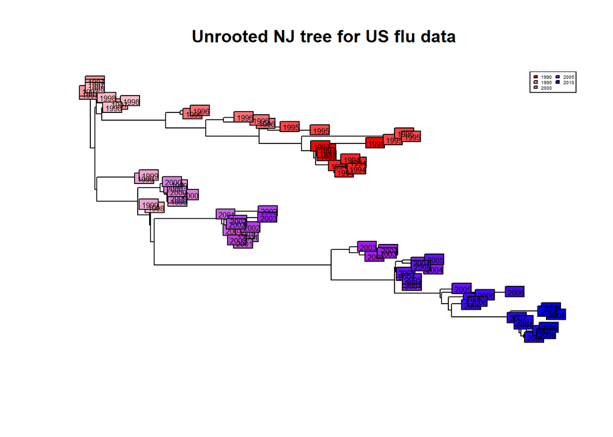

```r
# first, remove the tips so we can manually add colourful ones:
 plot(my_tree, show.tip = FALSE)
 title("Unrooted NJ tree for US flu data")
 # Create a custom colour palette (you can choose any colours here):
 myPal <- colorRampPalette(c("red", "pink", "purple", "blue"))
 # Add custom tip labels with the year
 tiplabels(meta$year, bg = num2col(meta$year, col.pal = myPal),
 cex = 0.5)
 # Turn your custom colours into a nice legend with 5 categories
 temp <- pretty(min(meta$year):max(meta$year), 5)
 legend("topright", fill = num2col(temp, col.pal = myPal),
 leg = temp, ncol = 2, cex=0.3)
```

```r
 # If you find that your legend is obstructing the tree, you can try changing the legend size (cex) or the legend position ("topright")
```

Notice in the above figure that the x-axis does NOT correspond to ancestry through time. This is because we have plotted an unrooted tree i.e. we did not provide the `nj` algorithm with a taxon defined as the ‘most ancient’ split in the tree to root it by. When plotting unrooted trees, it is best to clearly display them as such - to do this you can add `type = "unrooted"` to the plot command. In the below figure, the tree is no longer arranged left->right and so it’s more obvious that you are showing an unrooted tree.

```r
is.rooted(my_tree)
```

```
## [1] FALSE
```

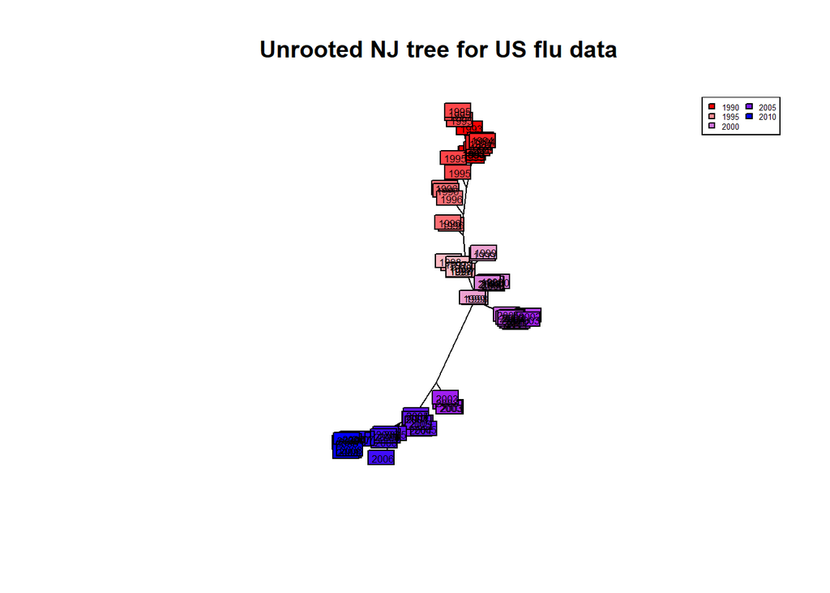

```r
plot(my_tree, type = "unrooted", show.tip = FALSE)
title("Unrooted NJ tree for US flu data")
tiplabels(meta$year, bg = num2col(meta$year, col.pal = myPal),
 cex = 0.5)
legend("topright", fill = num2col(temp, col.pal = myPal),
 leg = temp, ncol = 2, cex=0.4)
```

Since we do have years for our sequences (in the metadata) it is possible, and probably preferred, to create a rooted phylogeny. To do this, any of the oldest (1993) sequences would be a good choice of root.

8. Root and plot your `nj` phylogeny. Remember that the sequences are roughly ordered by year, so you want to choose one of the early ones to root by (you can confirm this by looking at the object `meta`).

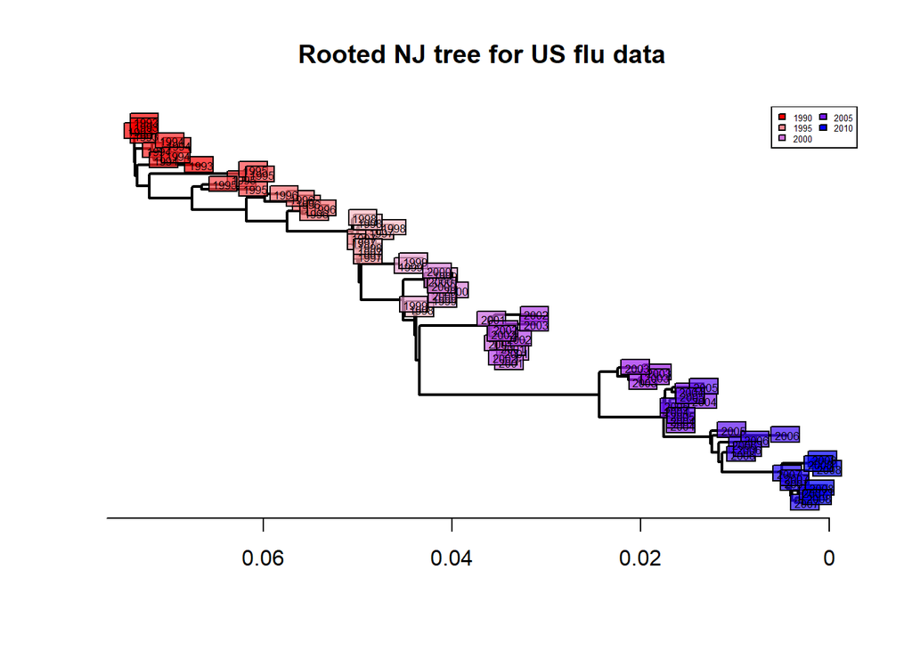

```r
# Here I root by the first sequence, but you could pick any of the first 5 (all 1993). You can also use e.g. 'out=1' to select the first sequence, rather than using the name.
my_tree2 <- root(my_tree, out = "CY013200", resolve.root = TRUE)
# Ladderize again for that nice plot layout
my_tree2 <- ladderize(my_tree2)

plot(my_tree2, show.tip = FALSE, edge.width = 2)
title("Rooted NJ tree for US flu data")
# We add some transparency (transp) to the label boxes so we can see the ones underneath
tiplabels(meta$year, bg = transp(num2col(meta$year, col.pal = myPal),
0.7), cex = 0.5)
axisPhylo()
temp <- pretty(1993:2008, 5)
legend("topright", fill = num2col(temp, col.pal = myPal),
0.7, leg = temp, ncol = 2, cex=0.4)
```

Now that the tree is rooted we can think of the left side as ‘ancestral’ and the right side as ‘recent’.

There are a wide range of other approaches than `nj` available for building phylogenetic trees in R. If you get time, check out the extension tasks section below to explore several of these alternatives.

Task (iii): estimating a molecular clock

Rooted trees, such as the one we just made, can be used to estimate rates of evolution. Unlike a regular clock which measures the passing of seconds, minutes or hours, a ‘molecular clock’ measures the accumulation of genetic mutations. To estimate the clock rate of our rooted tree, we can perform a regression over all tips of the number of mutations from the root against the time since the root.

9. Estimate the clock rate of your rooted influenza tree

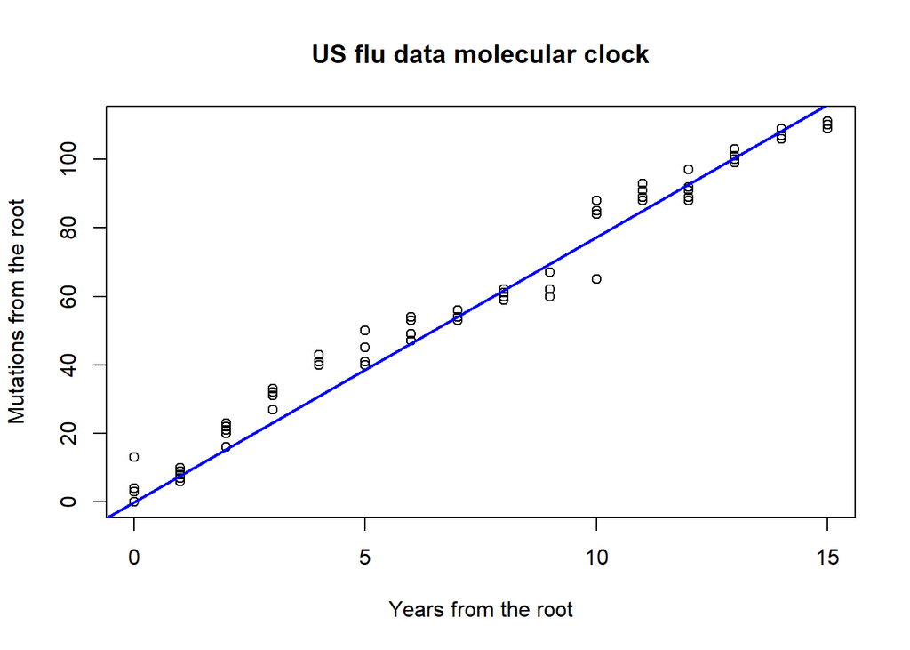

```r
# First, we plot the regression of mutations against time:

# How many mutations between each tip and the root?
mutFromRoot <- as.matrix(dist.dna(seqs, model="N"))[1,]
# How many years passed between each tip and the root?
yearFromRoot <- meta$year-meta$year[1]
plot(mutFromRoot~yearFromRoot, xlab="Years from the root",
ylab="Mutations from the root", main="US flu data molecular clock")

# Then we perform a regression of these quantities, and add to the plot. It should fit the points.
mclock <- lm(mutFromRoot~-1+yearFromRoot)
abline(mclock, col="blue",lwd=2)
```

```r
# What are the regression coefficients?
summary(mclock)
```

```
##
## Call:
## lm(formula = mutFromRoot ~ -1 + yearFromRoot)
##
## Residuals:
##     Min      1Q  Median      3Q     Max
## -12.327  -1.577   1.004   6.386  13.000
##
## Coefficients:
##              Estimate Std. Error t value Pr(>|t|)
## yearFromRoot  7.73274    0.07443   103.9   <2e-16 ***
## ---
## Signif. codes:  0 '***' 0.001 '**' 0.01 '*' 0.05 '.' 0.1 ' ' 1
##
## Residual standard error: 5.86 on 79 degrees of freedom
## Multiple R-squared:  0.9927, Adjusted R-squared:  0.9926
## F-statistic: 1.079e+04 on 1 and 79 DF,  p-value: < 2.2e-16
```

```r
mclock$coefficients
```

```
## yearFromRoot
##     7.732742
```

```r
mclock$coefficients/ncol(seqs)
```

```
## yearFromRoot
##  0.004545998
```

```r
365/mclock$coefficients
```

```
## yearFromRoot
##     47.20189
```

The coefficient of `yearFromRoot` is ~7.7. This is our estimate of the number of substitutions per year for the HA segment of the H3N2 influenza genomes. Use this result to answer the following questions:

- What is the substitution rate per site per year?
- Therefore, how many days would you expect it to take to accumulate 1 mutation in a transmission chain?
- Given your answers above and the fact that the generation time of influenza is 2-3 days, do you think that reconstructing influenza transmission trees from HA sequences is a good approach?

## Introduction: maximum parsimony phylogenies

An alternative to a distance-based phylogeny is a maximum parsimony phylogeny.

In general terms, the scientific principle of parsimony can be described as a belief that the best explanation of your data is equal to the simplest possible explanation that is consistent with that data. Maximum parsimony phylogenetic reconstruction therefore seeks trees that minimize the number of evolutionary changes (substitutions) between ancestor and descendant. This makes for a simple and easy-to-motivate methodology, that is most appropriate for sequences with low divergence i.e. most sequences are very similar to one another.

In an ideal world we would search over the space of all possible trees to find the one which is most parsimonious. However, in reality this is usually computationally impossible unless you have very few tips in your tree. Many algorithms have been designed to instead search broadly over this space in a clever way - to try and find a decently parsimonious tree without needing to check them all. These algorithms generally take a strategy of (1) pick an initial tree and calculate it’s parsimony, (2) propose some small changes to the tree and calculate the new tree’s parsimony, (3) keep the new tree if it leads to a better parsimony, and (4) repeat until the parsimony score stops improving.

Parsimony-based phylogenetic reconstruction is implemented in the package `phangorn`. It requires a tree (in ape’s format, i.e. a phylo object) and the original DNA sequences in `phangorn`’s own format, `phyDat`. We convert the data and generate a tree to initialize the method:

10. Create a maximum parsimony tree for the US flu data using the package `phangorn`. This requires an initial tree (you can use `ape` to make a neighbor-joining tree for this, as in the previous section) as well as the original DNA sequences, which must be converted to `phangorn`’s `phyDat` format, as follows:

```r
seqs2 <- as.phyDat(seqs)
class(seqs2)
```

```
## [1] "phyDat"
```

```r
seqs2
```

```
## 80 sequences with 1701 character and 269 different site patterns.
## The states are a c g t
```

```r
#make the initial tree
tree_init <- nj(dist.dna(seqs, model = "raw"))
tree_init
```

```
##
## Phylogenetic tree with 80 tips and 78 internal nodes.
##
## Tip labels:
##   CY013200, CY013781, CY012128, CY013613, CY012160, CY012272, ...
##
## Unrooted; includes branch lengths.
```

```r
#The parsimony of the inital tree is given by:
parsimony(tree_init, seqs2)
```

```
## [1] 422
```

```r
# Now perform the parsimony search
tree_parsim <- optim.parsimony(tree_init, seqs2)
```

```
## Final p-score 420 after  2 nni operations
```

```r
tree_parsim
```

```
##
## Phylogenetic tree with 80 tips and 76 internal nodes.
##
## Tip labels:
##   CY013200, CY013781, CY012128, CY013613, CY012160, CY012272, ...
##
## Unrooted; no branch lengths.
```

The tree we get out will be unrooted without branch lengths. Here we find that the parsimony of the final tree is not much lower than the `nj` tree we started with, but that won’t always be the case. We can think of this as the methods (`nj` and `optim.parsimony`) relatively well agreeing on the best tree, which tends to happen for datasets with low divergence. As we have here!

11. Plot your maximum parsimony tree (same approach as for the `nj` trees).

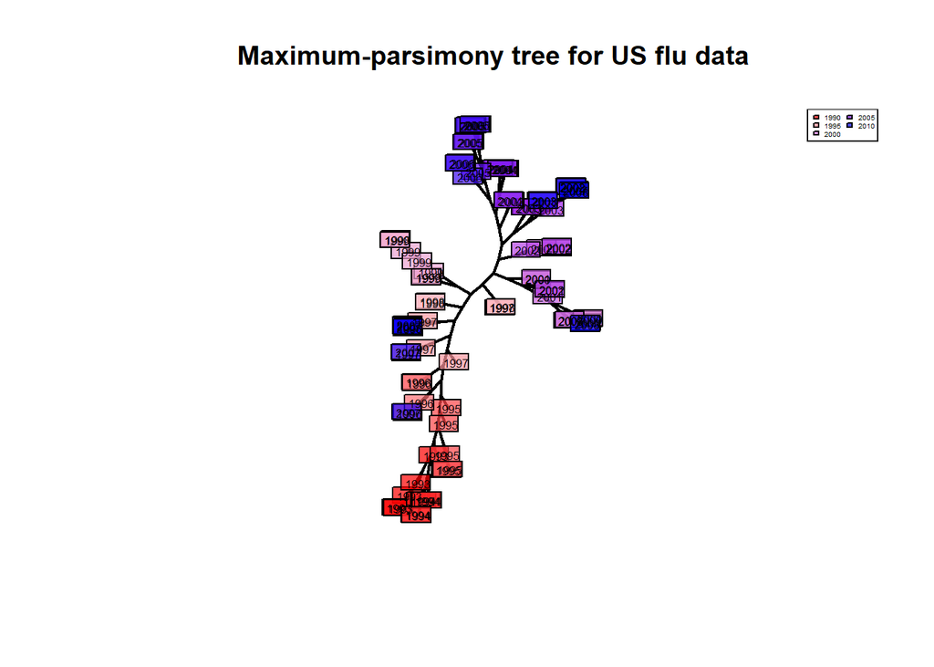

```r
plot(tree_parsim, type = "unr", show.tip = FALSE, edge.width = 2)
title("Maximum-parsimony tree for US flu data")
tiplabels(meta$year, bg = transp(num2col(meta$year, col.pal = myPal),
0.7), cex = 0.5, fg = "transparent")
temp <- pretty(1993:2008, 5)
legend("topright", fill = transp(num2col(temp, col.pal = myPal),
0.7), leg = temp, ncol = 2, bg = transp("white"), cex=0.3)
```

## Introduction: maximum likelihood phylogenies

Our final phylogenetic tree building approach is maximum likelihood. The idea here is very similar to maximum parsimony, in that we try to search over the space of all possible trees in a smart way to find the ‘best’ one. Except, this time we want to maximize some pre-defined likelihood function rather than maximizing parsimony.

A big benefit of this approach is that the likelihood to be maximized can be defined by any model of sequence evolution we choose, which makes it much more flexible. As well as optimizing over the space of trees, we can also simultaneously optimize over the parameters of our chosen model - to find the best tree and the best model parameters at the same time. A drawback, however, is that this means we need to decide what is the most appropriate model to use.

A common choice is the GTR + $\Gamma$(4) model (GTR = global reversible time). In this model, all possible substitutions (all transitions, transversions) are allowed to have different rates as well as the substitution rate being allowed to vary across sites. It is therefore a very flexible model.

Like maximum parsimony, maximum likelihood tree reconstruction can be performed with the `phangorn` package. Again, we require an initial tree and the DNA sequences.

```r
# phyDat format, same as before:
seqs2 <- as.phyDat(seqs)

#make the initial tree
tree_init <- nj(dist.dna(seqs, model = "TN93"))

#To begin the optimization procedure, we need to know the likelihood of the initial tree
pml(tree_init, seqs2, k = 4)
```

```
## model: JC+G(4)
## loglikelihood: -5641.785
## unconstrained loglikelihood: -4736.539
## Discrete gamma model
## Number of rate categories: 4
## Shape parameter: 1
##
## Rate matrix:
##   a c g t
## a 0 1 1 1
## c 1 0 1 1
## g 1 1 0 1
## t 1 1 1 0
##
## Base frequencies:
##    a    c    g    t
## 0.25 0.25 0.25 0.25
```

At this point, you may notice that the likelihood of your initial tree is `NaN`. This needs to be fixed, but isn’t a big problem. It is caused by missing data (missing or error bases) in our original sequences. So, we should remove them before continuing (even if you didn’t get a `NaN` likelihood, you should remove them so they aren’t a problem later!).

13. Find the location of the missing bases in the data. Plot them, and remove them.

```r
# First, find the location of the missing/incorrect bases (anything that isn't a,t,g,c)
na.posi <- which(apply(as.character(seqs), 2, function(e) any(!e %in%
                                                                 c("a", "t", "g", "c"))))
na.posi
```

```
##   [1]    1    2    3    4    5    6    7    8    9   10   11   12   13   14   15
##  [16]   16   17   18   19   20   21   22   23   24   25   26   27   28   29   30
##  [31]   31   32   33   34   35   36   37   38   39   40   41   42   43   44   45
##  [46]   46   47   48   49   50   51   52   53   54   55   56   57   58   59   60
##  [61]   61   62   63   64   65   66   67   68   69   70   71   72   73   74   75
##  [76]   76   77   78   79   80   81   82   83   84   85   86   87   88   89   90
##  [91]   91   92   93   94   95   96   97   98   99  259  334  336  460  721 1121
```

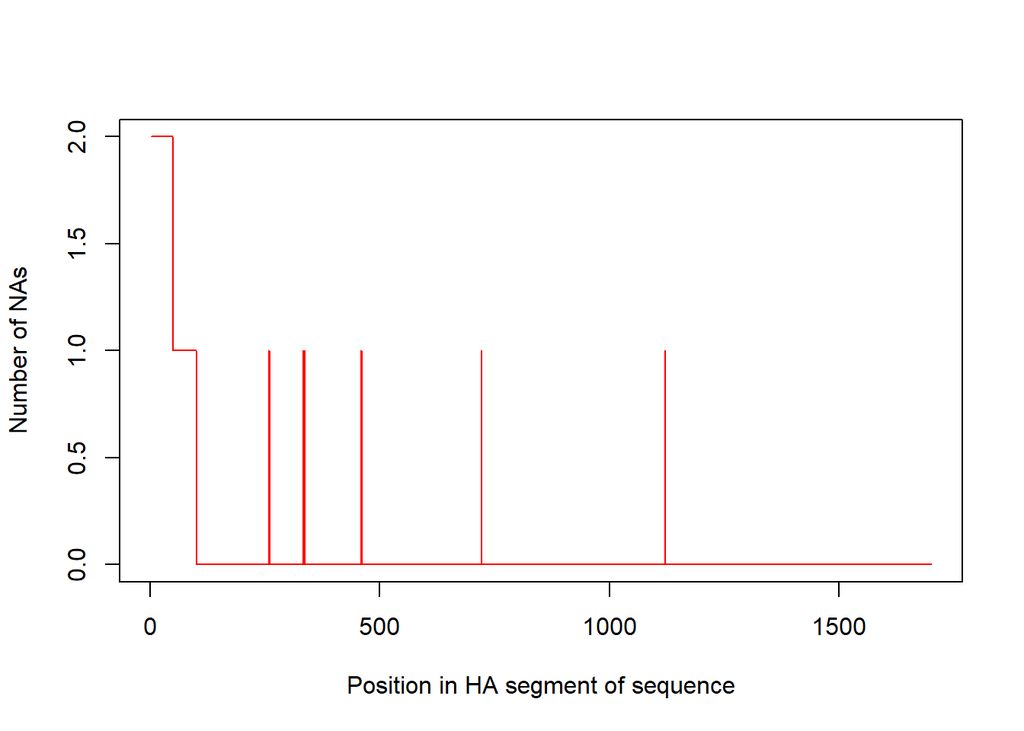

```r
# Plot them
temp <- apply(as.character(seqs), 2, function(e) sum(!e %in% c("a", "t", "g", "c")))
plot(temp, type = "l", col = "red", xlab = "Position in HA segment of sequence",
ylab = "Number of NAs")
```

```r
# Remove them
seqs3 <- seqs[, -na.posi]
seqs3
```

```
## 80 DNA sequences in binary format stored in a matrix.
##
## All sequences of same length: 1596
##
## Labels:
## CY013200
## CY013781
## CY012128
## CY013613
## CY012160
## CY012272
## ...
##
## Base composition:
##     a     c     g     t
## 0.340 0.197 0.226 0.238
## (Total: 127.68 kb)
```

```r
# Aha! Looks much better now. Before:
table(as.character(seqs))
```

```
##
##     -     a     c     g     k     m     r     s     t     w
##   147 45595 27170 30613     1     2     1     1 32549     1
```

```r
# After:
table(as.character(seqs3))
```

```
##
##     a     c     g     t
## 43402 25104 28828 30346
```

```r
# Don't forget! Change to phyDat format
seqs4 <- as.phyDat(seqs3)
```

It turns out most of the missing bases are towards the beginning of the alignment: this is usual.

Now we’re ready to search for a maximum likelihood tree.

14. Find a maximum likelihood phylogeny for the US flu data, using `optim.pml`. Remember to start with a new initial tree, using your new sequences with missing data removed.

```r
#Make the initial tree
tree_init <- nj(dist.dna(seqs3, model = "TN93"))
#Find its (log) likelihood
lh_init <- pml(tree_init, seqs4, k = 4)
lh_init
```

```
## model: JC+G(4)
## loglikelihood: -5184.119
## unconstrained loglikelihood: -4043.367
## Discrete gamma model
## Number of rate categories: 4
## Shape parameter: 1
##
## Rate matrix:
##   a c g t
## a 0 1 1 1
## c 1 0 1 1
## g 1 1 0 1
## t 1 1 1 0
##
## Base frequencies:
##    a    c    g    t
## 0.25 0.25 0.25 0.25
```

```r
# Find the max. likelihood tree. We optimize the tree (optNni = TRUE), the base frequencies (optBf=TRUE), the substitution rates (optQ=TRUE) and assume a gamma distribution for the variation in substitution rates across sites (optGamma = TRUE).
fit <- optim.pml(lh_init, optNni = TRUE, optBf = TRUE, optQ = TRUE, optGamma = TRUE)
```

```
## optimize edge weights:  -5184.094 --> -5166.996
## optimize base frequencies:  -5166.996 --> -5121.313
## optimize rate matrix:  -5121.313 --> -4933.871
## optimize shape parameter:  -4933.871 --> -4919.646
## optimize edge weights:  -4919.646 --> -4919.326
## optimize topology:  -4919.326 --> -4916.187  NNI moves:  2
## optimize base frequencies:  -4916.187 --> -4915.89
## optimize rate matrix:  -4915.89 --> -4915.868
## optimize shape parameter:  -4915.868 --> -4915.867
## optimize edge weights:  -4915.867 --> -4915.867
## optimize topology:  -4915.867 --> -4915.867  NNI moves:  0
## optimize base frequencies:  -4915.867 --> -4915.866
## optimize rate matrix:  -4915.866 --> -4915.866
## optimize shape parameter:  -4915.866 --> -4915.866
## optimize edge weights:  -4915.866 --> -4915.866
## optimize base frequencies:  -4915.866 --> -4915.866
## optimize rate matrix:  -4915.866 --> -4915.866
## optimize shape parameter:  -4915.866 --> -4915.866
## optimize edge weights:  -4915.866 --> -4915.866
## optimize base frequencies:  -4915.866 --> -4915.866
## optimize rate matrix:  -4915.866 --> -4915.866
## optimize shape parameter:  -4915.866 --> -4915.866
## optimize edge weights:  -4915.866 --> -4915.866
```

```r
fit
```

[output not shown]

```r
names(fit) # what are the components of the results object?
```

```
##  [1] "logLik"    "inv"       "k"         "shape"     "Q"         "bf"
##  [7] "rate"      "siteLik"   "weight"    "g"         "w"         "eig"
## [13] "data"      "model"     "INV"       "ll.0"      "tree"      "lv"
## [19] "call"      "df"        "wMix"      "llMix"     "ASC"       "site.rate"
```

The results object (here named `fit`) contains not just the optimal tree (`fit$tree`), but also other useful info. Take some time to explore these.

Before choosing this as our favourite maximum likelihood tree, we can confirm that the optimized tree is better than the initial one using ANOVA and AIC:

```r
# ANOVA
anova(lh_init, fit)
```

```
## Likelihood Ratio Test Table
##   Log lik.  Df Df change Diff log lik. Pr(>|Chi|)
## 1  -5184.1 158
## 2  -4915.9 166         8        536.51  < 2.2e-16 ***
## ---
## Signif. codes:  0 '***' 0.001 '**' 0.01 '*' 0.05 '.' 0.1 ' ' 1
```

```r
# Compare AIC
AIC(lh_init)
```

```
## [1] 10684.24
```

```r
AIC(fit)
```

```
## [1] 10163.73
```

Indeed, ANOVA has a good p-value and the AIC of the new tree is better than the initial one. Great news! We have obtained an improved tree.

14. Lastly, plot your maximum likelihood phylogeny for the US flu data (just like for the other methods).

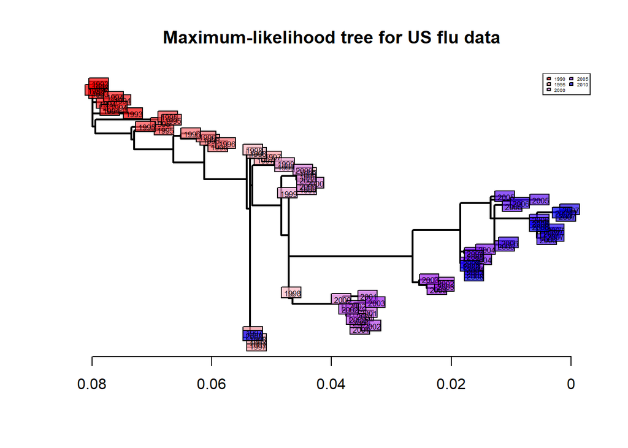

```r
tree_ml <- root(fit$tree, 1)
plot(tree_ml, show.tip = FALSE, edge.width = 2)
title("Maximum-likelihood tree for US flu data")
tiplabels(meta$year, bg = transp(num2col(meta$year, col.pal = myPal),
0.7), cex = 0.5, fg = "transparent")
axisPhylo()
temp <- pretty(1993:2008, 5)
legend("topright", fill = transp(num2col(temp, col.pal = myPal),
0.7), leg = temp, ncol = 2, cex=0.3)
```

Overall, we find that for this data set, all methods return fairly similar trees. Our data is relatively simple, with few samples and low diversity, so this is not unexpected. For larger and more complex data, you will likely find much more stark differences between different methods. It’s usually a good idea to test out a few different tree building approaches before drawing any conclusions about your data.

**How do we choose between methods?**

- **Distance based methods.** *Pros:* the fastest method, and fairly flexible too (can use different distance measures). *Cons:* no real way to compare between different distance-based methods and find the ‘best’.
- **Maximum parsimony.** *Pros:* intuitive, works well for data with small amounts of genetic variation. *Cons:* simplistic evolutionary model, computationally intensive, works poorly for data with large amounts of genetic variation or where mutation rates vary across the tree.
- **Maximum likelihood.** *Pros:* very flexible - can use any model of evolution, can perform model selection, usually works well. *Cons:* computationally intensive.

A popular branch of methods for tree reconstruction that we have not covered here are Bayesian methods - such as [BEAST](https://beast.community) and [BEAST2](https://www.beast2.org/). These can be seen as an extension to maximum likelihood methods, except that instead of finding the single tree with ‘best’ likelihood, they seek samples of trees and model parameters which are most consistent with both the data and any prior knowledge you might have of the tree or parameters. Since the focus of our module is transmission inference and these methods are slightly more complex, we will not cover them here. However, these are very popular methods so worth a look if you are interested in this area.

# Your own analysis: reconstructing TB and SARS-CoV-2 phylogenetic trees

1. **Use what you’ve learned from this tutorial to build phylogenies for the Roetzer TB genomes and/or the SARS-CoV-2 genomes from exercise 2**
- Try building phylogenies using different methods, as in step 1.
- How different do the phylogenies look?

Remember that we don’t expect you to finish the whole tutorial for all 3 datasets within this single time slot. But hopefully you can make a good start, ask lots of questions, and then continue later if you want to.

## Extension tasks and additional reading

A. The phylogenies we built above were not linked to time, though generally in transmission inference we have a time point associated with each sequence (e.g. the time of sampling). Check out the extension exercise linked from the module webpage for a tutorial on building timed trees.

B. Here are several alternatives to `nj` for building phylogenetic trees:

- `bionj` (`ape` library): an improved version of Neighbor-Joining.
- `fastme.bal` and `fastme.ols` (`ape` library): minimum evolution algorithms.
- `hclust` (`stats` library): classical hierarchical clustering algorithms including single linkage, complete linkage, UPGMA, and others.

C. Development of methods for comparison of phylogenetic trees is an active area of research. Investigate the R packages ape and treespace, or look up alternatives, for ways to compare trees, and apply these to your TB/COVID trees. Here is a document about treespace: https://cran.r-project.org/web/packages/treespace/vignettes/introduction.html